# Happiness Analysis

Nidhi Patni, Venkata Sai Mounish Ennamuri, Hema Pavani Vempati

2023-04-28

# TEAM MEMBERS

1. Nidhi Jitendra Patni
2. Venkata Sai Mounish Ennamuri
3. Hema Pavani Vempati

# BUSINESS CONTEXT

The World Happiness Report provides important insights into the happiness and well-being of people around the world, which can inform business strategies and policy decisions that contribute to a more sustainable and prosperous global economy.

# PROBLEM DESCRIPTION

The World Happiness Report seeks to address is to measure and understand the levels of happiness and well-being of people around the world and the factors that contribute to it. This is important because happiness and well-being are fundamental human needs, and understanding the factors that contribute to them can inform policy decisions and interventions that improve people’s lives. Establishing a model that can predict the Happiness Index of a country based on factors such as social, economic, health etc. can go a long way in helping policy decisions. Our goal is to establish this model. (Limitation: Data used only for year 2021)

# DATASET DESCRIPTION

The World Happiness Report dataset consist of several variables, such as:

1. Country : The name of the country
2. Region : Region to which the country belongs
3. Ladder Score : the overall score of happiness in a country on an average from the collective responses of the people based on the factors impacting well being.
4. GDP : the gross domestic product per capita in purchasing power parity (PPP) adjusted dollars.
5. Freedom : the perceived freedom to make life choices in the country.
6. Corruption : the perceived level of corruption in the government and business sectors of the country.
7. Life Expectancy : Healthy life expectancy at birth
8. Social Support : the perceived social support (ability to count on others) in the country
9. Dystopia residual : the extent to which the country’s happiness score deviates from an imagined dystopian society with the least happy possible outcomes.
10. Generosity : the perceived generosity of people in the country.

# STEP 1: INCLUDING LIBRARIES:

```r
library(MASS)
library(tidyverse)
library(reshape2)
```

```r
library(lattice)
library(dplyr)
library(ggplot2)
library(data.table)
library(DataExplorer)
library(viridis)
library(corrplot)
library(car)
```

# STEP 2: DATA PREPARATION:

# Set Directory

```r
setwd("C:/Users/nidsp/OneDrive - Illinois Institute of Technology/Desktop/Happiness 2021 Analysis")
```

# Data Loading

```r
OriginalData <- read.csv("world-happiness-report-2021.csv", na.strings = c('N/A'))
```

# Checking data type

```r
print(class(OriginalData))
```

```
## [1] "data.frame"
```

# Reviewing the data

```r
OriginalData <- as.data.table(OriginalData)
OriginalData
```

```
##      Country.name Regional.indicator Ladder.score
##   1:      Finland     Western Europe        7.842
##   2:      Denmark     Western Europe        7.620
##   3:  Switzerland     Western Europe        7.571
##   4:      Iceland     Western Europe        7.554
##   5:  Netherlands     Western Europe        7.464
##  ---
## 145:      Lesotho Sub-Saharan Africa        3.512
## 146:     Botswana Sub-Saharan Africa        3.467
## 147:       Rwanda Sub-Saharan Africa        3.415
## 148:     Zimbabwe Sub-Saharan Africa        3.145
## 149:  Afghanistan         South Asia        2.523
##      Standard.error.of.ladder.score upperwhisker lowerwhisker
##   1:                          0.032        7.904        7.780
##   2:                          0.035        7.687        7.552
```

[output cut: 81 more lines]

# Finding number of observations and columns in dataset

```r
dim(OriginalData)
```

```
## [1] 149  20
```

> There are 149 observations and 20 features in dataset.

# Reviewing the structure of data frame

```r
str(OriginalData)
```

```
## Classes 'data.table' and 'data.frame':   149 obs. of  20 variables:
##  $ Country.name                              : chr  "Finland" "Denmark" "Switzerland" "Iceland" ...
##  $ Regional.indicator                        : chr  "Western Europe" "Western Europe" "Western Europe" "Western Europe" ...
##  $ Ladder.score                              : num  7.84 7.62 7.57 7.55 7.46 ...
##  $ Standard.error.of.ladder.score            : num  0.032 0.035 0.036 0.059 0.027 0.035 0.036 0.037 0.04 0.036 ...
##  $ upperwhisker                              : num  7.9 7.69 7.64 7.67 7.52 ...
##  $ lowerwhisker                              : num  7.78 7.55 7.5 7.44 7.41 ...
##  $ Logged.GDP.per.capita                     : num  10.8 10.9 11.1 10.9 10.9 ...
##  $ Social.support                            : num  0.954 0.954 0.942 0.983 0.942 0.954 0.934 0.908 0.948 0.934 ...
##  $ Healthy.life.expectancy                   : num  72 72.7 74.4 73 72.4 73.3 72.7 72.6 73.4 73.3 ...
##  $ Freedom.to.make.life.choices              : num  0.949 0.946 0.919 0.955 0.913 0.96 0.945 0.907 0.929 0.908 ...
##  $ Generosity                                : num  -0.098 0.03 0.025 0.16 0.175 0.093 0.086 -0.034 0.134 0.042 ...
##  $ Perceptions.of.corruption                 : num  0.186 0.179 0.292 0.673 0.338 0.27 0.237 0.386 0.242 0.481 ...
##  $ Ladder.score.in.Dystopia                  : num  2.43 2.43 2.43 2.43 2.43 2.43 2.43 2.43 2.43 2.43 ...
##  $ Explained.by..Log.GDP.per.capita          : num  1.45 1.5 1.57 1.48 1.5 ...
##  $ Explained.by..Social.support              : num  1.11 1.11 1.08 1.17 1.08 ...
##  $ Explained.by..Healthy.life.expectancy     : num  0.741 0.763 0.816 0.772 0.753 0.782 0.763 0.76 0.785 0.782 ...
##  $ Explained.by..Freedom.to.make.life.choices: num  0.691 0.686 0.653 0.698 0.647 0.703 0.685 0.639 0.665 0.64 ...
##  $ Explained.by..Generosity                  : num  0.124 0.208 0.204 0.293 0.302 0.249 0.244 0.166 0.276 0.215 ...
##  $ Explained.by..Perceptions.of.corruption   : num  0.481 0.485 0.413 0.17 0.384 0.427 0.448 0.353 0.445 0.292 ...
##  $ Dystopia...residual                       : num  3.25 2.87 2.84 2.97 2.8 ...
##  - attr(*, ".internal.selfref")=<externalptr>
```

> All Columns are assigned with correct data types.

# Loading required data in data frame.

```r
data <- subset(OriginalData, select=c("Country.name",
                              "Regional.indicator",
                              "Ladder.score",
                              "Logged.GDP.per.capita",
                              "Social.support",
                              "Healthy.life.expectancy",
                              "Freedom.to.make.life.choices",
                              "Generosity",
                              "Perceptions.of.corruption",
                              "Dystopia...residual"))

data
```

```
##      Country.name Regional.indicator Ladder.score Logged.GDP.per.capita
##   1:      Finland     Western Europe        7.842                10.775
##   2:      Denmark     Western Europe        7.620                10.933
##   3:  Switzerland     Western Europe        7.571                11.117
##   4:      Iceland     Western Europe        7.554                10.878
##   5:  Netherlands     Western Europe        7.464                10.932
##  ---
## 145:      Lesotho Sub-Saharan Africa        3.512                 7.926
## 146:     Botswana Sub-Saharan Africa        3.467                 9.782
## 147:       Rwanda Sub-Saharan Africa        3.415                 7.676
## 148:     Zimbabwe Sub-Saharan Africa        3.145                 7.943
## 149:  Afghanistan         South Asia        2.523                 7.695
##      Social.support Healthy.life.expectancy Freedom.to.make.life.choices
##   1:          0.954                  72.000                        0.949
##   2:          0.954                  72.700                        0.946
```

[output cut: 21 more lines]

# Renaming the names of columns for better readability

```r
data <- data %>% rename( Country=Country.name,
                         Region=Regional.indicator,
                         Happiness_score=Ladder.score,
                         GDP=Logged.GDP.per.capita,
                         Social_support=Social.support,
                         Life_expectancy=Healthy.life.expectancy,
                         Freedom=Freedom.to.make.life.choices,
                         Corruption=Perceptions.of.corruption,
                         Dystopia_residual=Dystopia...residual)

data
```

```
##          Country             Region Happiness_score    GDP Social_support
##   1:     Finland     Western Europe           7.842 10.775          0.954
##   2:     Denmark     Western Europe           7.620 10.933          0.954
##   3: Switzerland     Western Europe           7.571 11.117          0.942
##   4:     Iceland     Western Europe           7.554 10.878          0.983
##   5: Netherlands     Western Europe           7.464 10.932          0.942
##  ---
## 145:     Lesotho Sub-Saharan Africa           3.512  7.926          0.787
## 146:    Botswana Sub-Saharan Africa           3.467  9.782          0.784
## 147:      Rwanda Sub-Saharan Africa           3.415  7.676          0.552
## 148:    Zimbabwe Sub-Saharan Africa           3.145  7.943          0.750
## 149: Afghanistan         South Asia           2.523  7.695          0.463
##      Life_expectancy Freedom Generosity Corruption Dystopia_residual
##   1:          72.000   0.949     -0.098      0.186             3.253
##   2:          72.700   0.946      0.030      0.179             2.868
##   3:          74.400   0.919      0.025      0.292             2.839
##   4:          73.000   0.955      0.160      0.673             2.967
##   5:          72.400   0.913      0.175      0.338             2.798
##  ---
## 145:          48.700   0.715     -0.131      0.915             1.800
## 146:          59.269   0.824     -0.246      0.801             0.648
## 147:          61.400   0.897      0.061      0.167             1.095
## 148:          56.201   0.677     -0.047      0.821             1.205
## 149:          52.493   0.382     -0.102      0.924             1.895
```

# Reviewing summary of data

```r
summary(data)
```

```
##    Country             Region          Happiness_score      GDP
##  Length:149         Length:149         Min.   :2.523   Min.   : 6.635
##  Class :character   Class :character   1st Qu.:4.852   1st Qu.: 8.541
##  Mode  :character   Mode  :character   Median :5.534   Median : 9.569
##                                        Mean   :5.533   Mean   : 9.432
##                                        3rd Qu.:6.255   3rd Qu.:10.421
##                                        Max.   :7.842   Max.   :11.647
##  Social_support   Life_expectancy    Freedom         Generosity
##  Min.   :0.4630   Min.   :48.48   Min.   :0.3820   Min.   :-0.28800
##  1st Qu.:0.7500   1st Qu.:59.80   1st Qu.:0.7180   1st Qu.:-0.12600
##  Median :0.8320   Median :66.60   Median :0.8040   Median :-0.03600
##  Mean   :0.8147   Mean   :64.99   Mean   :0.7916   Mean   :-0.01513
##  3rd Qu.:0.9050   3rd Qu.:69.60   3rd Qu.:0.8770   3rd Qu.: 0.07900
##  Max.   :0.9830   Max.   :76.95   Max.   :0.9700   Max.   : 0.54200
##    Corruption     Dystopia_residual
##  Min.   :0.0820   Min.   :0.648
##  1st Qu.:0.6670   1st Qu.:2.138
##  Median :0.7810   Median :2.509
##  Mean   :0.7274   Mean   :2.430
##  3rd Qu.:0.8450   3rd Qu.:2.794
##  Max.   :0.9390   Max.   :3.482
```

# Descriptive Statistics

```r
Mean_Happiness_Score <- mean(data$Happiness_score)
Variance_Happiness_Score <- var(data$Happiness_score)
StdDev_Happiness_Score <- sd(data$Happiness_score)
Median_Happiness_Score <- median(data$Happiness_score)

cat("Mean Happiness score is ",Mean_Happiness_Score)
```

```
## Mean Happiness score is  5.532839
```

```r
cat("\nVariance of Happiness score is ",Variance_Happiness_Score)
```

```
##
## Variance of Happiness score is  1.153312
```

```r
cat("\nStandard Deviation of Happiness score is ",StdDev_Happiness_Score)
```

```
##
## Standard Deviation of Happiness score is  1.073924
```

```r
cat("\nMedian Happiness score is ",Median_Happiness_Score)
```

```
##
## Median Happiness score is  5.534
```

# STEP 3: DATA CLEANING

# Checking missing values

```r
MissingValueColumnName <- colnames(data)[colSums(is.na(data)) > 0]
NumberOfMissingValues <- sum(is.na(data))
cat("There are", NumberOfMissingValues, "Missing Values in Column name", MissingValueColumnName)
```

```
## There are 0 Missing Values in Column name
```

> There are no missing values, so no need of data cleaning.

# Unique values in Region

```r
# Get the unique values of a Region column
unique_values <- data %>% distinct(Region)

# Print the unique values
print(unique_values)
```

```
##                                 Region
##  1:                     Western Europe
##  2:              North America and ANZ
##  3:       Middle East and North Africa
##  4:        Latin America and Caribbean
##  5:         Central and Eastern Europe
##  6:                          East Asia
##  7:                     Southeast Asia
##  8: Commonwealth of Independent States
##  9:                 Sub-Saharan Africa
## 10:                         South Asia
```

# Combining Multiple similar named region into one

```r
# Creating data frame for unique region
dataRegion <- data
# change region to factor
dataRegion$Region <- as.factor(dataRegion$Region)
# combine south asia and southeast asia and east asia
dataRegion <- dataRegion %>% mutate(Region = fct_recode(Region,
                             # new name         old name
                             "Southeast Asia" = "South Asia",
                             "Southeast Asia" = "East Asia"))

# Get the unique values of a Region column


# Print the unique values
print(unique_values)
```

```
##                                 Region
##  1:                     Western Europe
##  2:              North America and ANZ
##  3:       Middle East and North Africa
##  4:        Latin America and Caribbean
##  5:         Central and Eastern Europe
##  6:                          East Asia
##  7:                     Southeast Asia
##  8: Commonwealth of Independent States
##  9:                 Sub-Saharan Africa
## 10:                         South Asia
```

# STEP 4: CHECKING NORMAL DISTRIBUTION OF TARGET VARIABLE

# 1. Checking distribution of target variable Happiness_score using Histogram as we know that target variable is a continuous variable

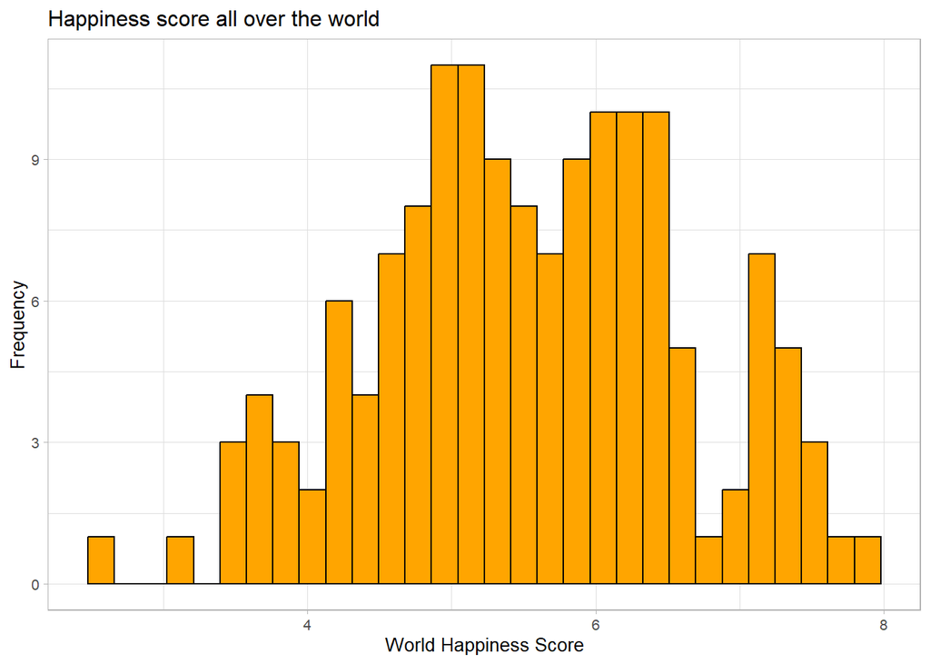

```r
ggplot(data=data, aes(data$Happiness_score,y = after_stat(count))) +
  geom_histogram( fill = "orange", color = "black", bins = 30)+
  theme_light(base_size = 10)+
  labs(title="Happiness score all over the world", x = "World Happiness Score", y = "Frequency")
```

# 2. Plot to check normal distribution of target variable

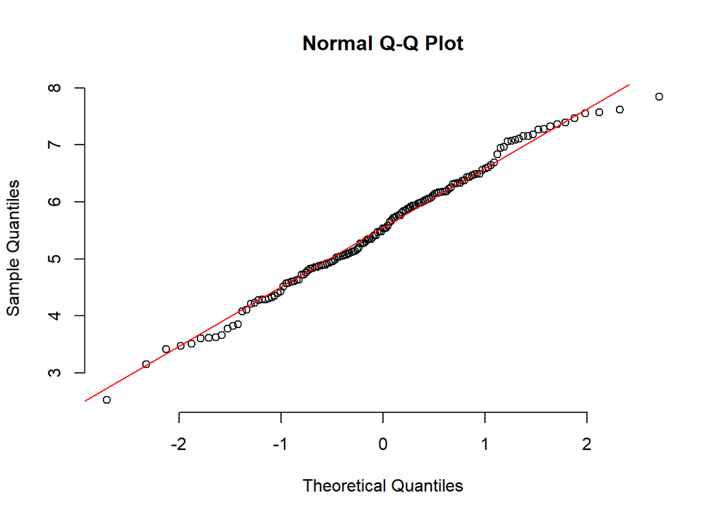

```r
qqnorm(data$Happiness_score, pch = 1, frame = FALSE)
qqline(data$Happiness_score, col = "red")
```

> In the above normal probability plot , the data points roughly follow a straight line which states that the data follows a normal distribution.

# 3. Checking normal distribution of target variable using Shapiro’s test.

```r
shapiro.test(data$Happiness_score)
```

```
##
##  Shapiro-Wilk normality test
##
## data:  data$Happiness_score
## W = 0.99125, p-value = 0.4893
```

> The output of this test will include a p-value. If the p-value is greater than 0.05, then we cannot reject the null hypothesis that the data is normally distributed. If the p-value is less than 0.05, then we can reject the null hypothesis and conclude that the data is not normally distributed. Here in this data, pvalue > 0.05 implying that the distribution of the data are not significantly different from normal distribution. In other words, we can assume the normality.

# STEP 5 : CHECKING OUTLIERS IN TARGET VARIABLE

# 1. Checking outliers in target variable using Boxplot

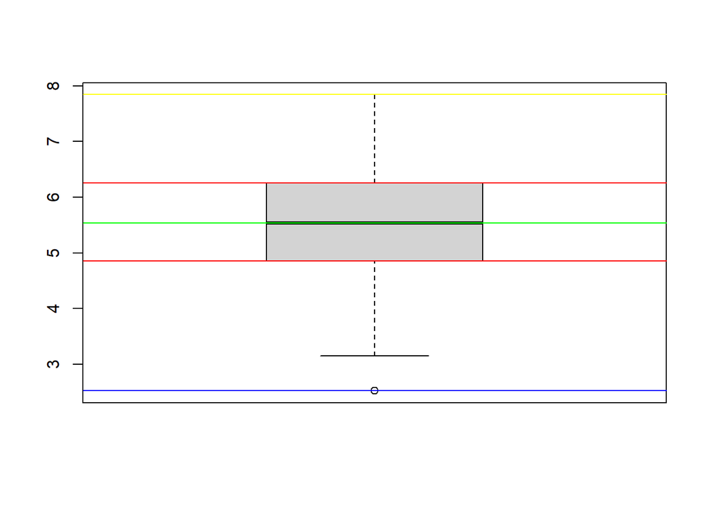

```r
boxplot(data$Happiness_score)
abline(h = min(data$Happiness_score), col = "Blue")
abline(h = max(data$Happiness_score), col = "Yellow")
abline(h = median(data$Happiness_score), col = "Green")
abline(h = quantile(data$Happiness_score, c(0.25, 0.75)), col = "Red")
```

> The resulting plot shows a box representing the interquartile range (IQR) of the Happiness_score variable, with whiskers extending to the minimum and maximum values within 1.5 times the IQR from the lower and upper quartiles, respectively. The horizontal reference lines are overlaid on the box plot, highlighting the minimum, maximum, median, and quartile values. By inspecting the plot, any values beyond the whiskers can be considered potential outliers. There is one data point beyond the whiskers, it should be investigated further to determine whether it is a true outliers in the data or not.

# 2. Checking outliers in target variable using Zscore

```r
#Standardizing Happiness score
Happiness_score_z_scores <- (data$Happiness_score - mean(data$Happiness_score)) / sd(data$Happiness_score)
# Find the data points with z-score greater than 3 (an arbitrary threshold)
Happiness_score_outliers <- data$Happiness_score[Happiness_score_z_scores > 3 | Happiness_score_z_scores < -3]
Happiness_score_outliers
```

```
## numeric(0)
```

> There are no outliers in the target variable Happiness score.

# STEP 6 : EXPLORATORY DATA ANALYSIS

# 1. Checking Top 10 and Bottom 10 Happiest Country

# 1.a. Top 10 Happiest country in the world

```r
Top_10_Happiest_Country <- data %>% select(Country,Region,Happiness_score) %>% head(n=10)
Top_10_Happiest_Country
```

```
##         Country                Region Happiness_score
##  1:     Finland        Western Europe           7.842
##  2:     Denmark        Western Europe           7.620
##  3: Switzerland        Western Europe           7.571
##  4:     Iceland        Western Europe           7.554
##  5: Netherlands        Western Europe           7.464
##  6:      Norway        Western Europe           7.392
##  7:      Sweden        Western Europe           7.363
##  8:  Luxembourg        Western Europe           7.324
##  9: New Zealand North America and ANZ           7.277
## 10:     Austria        Western Europe           7.268
```

# Bar plot is used to visualize the distribution of categorical variable Country with continuous variable Happiness Score for top 10 Happiest Countries in the world.

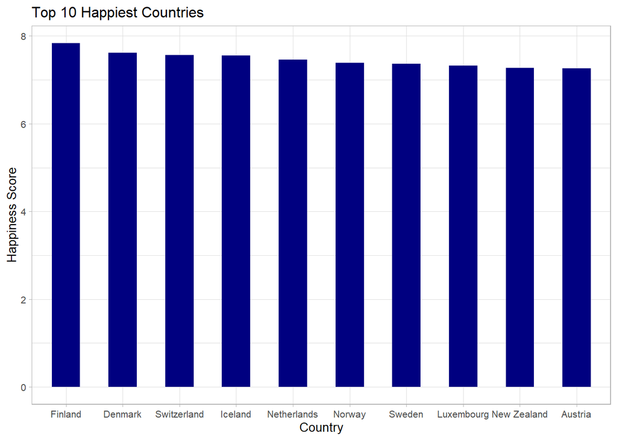

```r
ggplot(Top_10_Happiest_Country,aes(x=factor(Country,levels=Country),y=Happiness_score))+
  geom_bar(stat="identity",width=0.5,fill="navyblue")+
  theme(axis.text.x = element_text(angle=90, vjust=0.6))+
  theme_light(base_size = 10)+
  labs(title="Top 10 Happiest Countries",x="Country",y="Happiness Score")
```

> This plot can help us compare the happiness scores of different countries and understand which countries have the highest levels of happiness.

# 1.b. Bottom 10 Happiest country in the world

```r
Bottom_10_Happiest_Country <- data %>% select(Country,Region,Happiness_score) %>% tail(n=10)
Bottom_10_Happiest_Country
```

```
##         Country                       Region Happiness_score
##  1:     Burundi           Sub-Saharan Africa           3.775
##  2:       Yemen Middle East and North Africa           3.658
##  3:    Tanzania           Sub-Saharan Africa           3.623
##  4:       Haiti  Latin America and Caribbean           3.615
##  5:      Malawi           Sub-Saharan Africa           3.600
##  6:     Lesotho           Sub-Saharan Africa           3.512
##  7:    Botswana           Sub-Saharan Africa           3.467
##  8:      Rwanda           Sub-Saharan Africa           3.415
##  9:    Zimbabwe           Sub-Saharan Africa           3.145
## 10: Afghanistan                   South Asia           2.523
```

# Bar plot is used to visualize the distribution of categorical variable Country with continuous variable Happiness Score for bottom 10 Happiest Countries in the world.

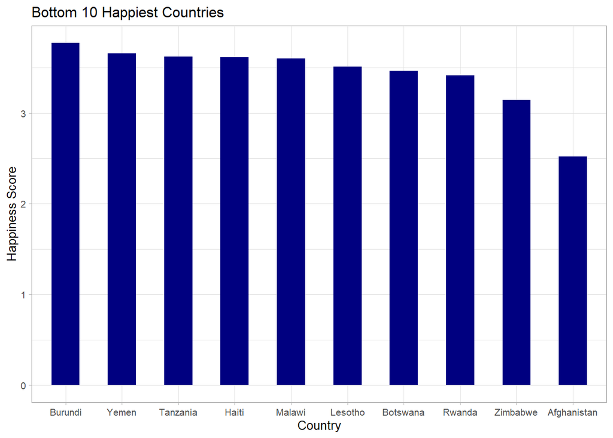

```r
ggplot(Bottom_10_Happiest_Country,aes(x=factor(Country,levels=Country),y=Happiness_score))+
  geom_bar(stat="identity",width=0.5,fill="navyblue")+
  theme(axis.text.x = element_text(angle=90, vjust=0.6))+
  theme_light(base_size = 10)+
  labs(title="Bottom 10 Happiest Countries",x="Country",y="Happiness Score")
```

> This plot can help us compare the happiness scores of different countries and understand which countries have the lowest levels of happiness.

# 2. EDA for each predictor variable like Life Expectancy, Freedom, Generosity, GDP, Social Support, Corruption, Dystopia Residual against target variable Happiness Score.

# 2.a. Happiness Score & Life Expectency

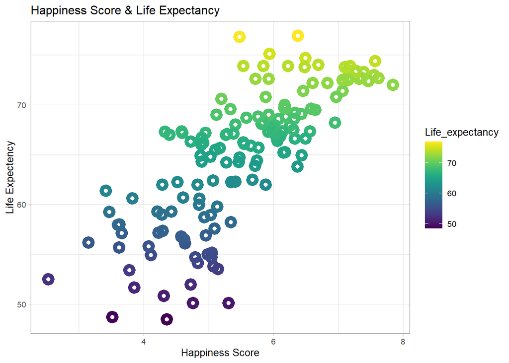

```r
ggplot(data = data, aes(x = Happiness_score, y =  Life_expectancy)) +
  geom_point(aes(color = Life_expectancy), show.legend = T, pch=1, stroke=3, size = 2) +
  theme_light(base_size = 10) + scale_color_viridis(discrete = F) +
  labs(title = "Happiness Score & Life Expectancy", fill = "Happiness Score",
       x = "Happiness Score" , y = "Life Expectency")
```

> We are using scatter plot to investigate the distribution between 2 continuous variable Happiness score and Life expectancy where each point represents a country.This plot shows that there appears to be a pretty significant relationship between Life Expectancy and the happiness score as the data points appear to show a positive trend.

# 2.b. Happiness Score & GDP

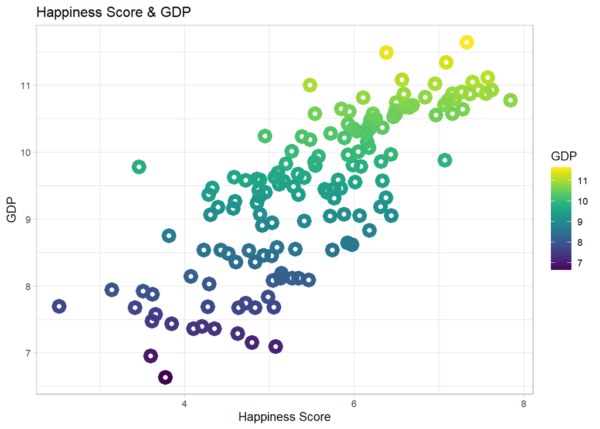

```r
ggplot(data = data, aes(x = Happiness_score, y =  GDP)) +
  geom_point(aes(color = GDP), show.legend = T, pch=1, stroke=3, size = 2) +
  theme_light(base_size = 10) + scale_color_viridis(discrete = F) +
  labs(title = "Happiness Score & GDP", fill = "Happiness Score",
       x = "Happiness Score" , y = "GDP")
```

> This plot shows that there appears to be a pretty significant relationship between GDP and the happiness score as the data points appear to show a positive trend.

# 2.c. Happiness Score & Social_support

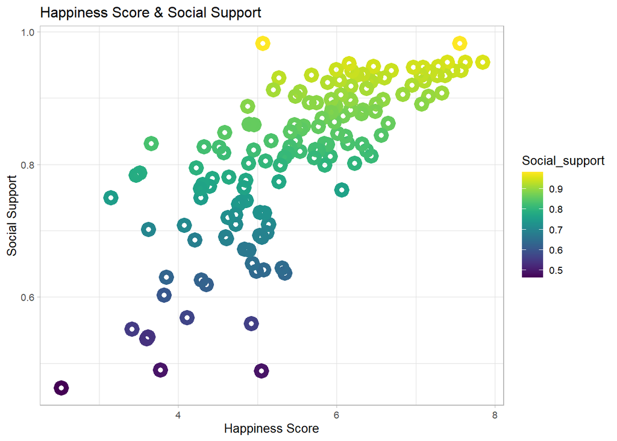

```r
ggplot(data = data, aes(x = Happiness_score, y =  Social_support)) +
  geom_point(aes(color = Social_support), show.legend = T, pch=1, stroke=3, size = 2) +
  theme_light(base_size = 10) + scale_color_viridis(discrete = F) +
  labs(title = "Happiness Score & Social Support", fill = "Happiness Score",
       x = "Happiness Score" , y = "Social Support")
```

> This plot shows that there appears to be a pretty significant relationship between Social Support and the happiness score as the data points appear to show a positive trend.

# 2.d. Happiness Score & Freedom

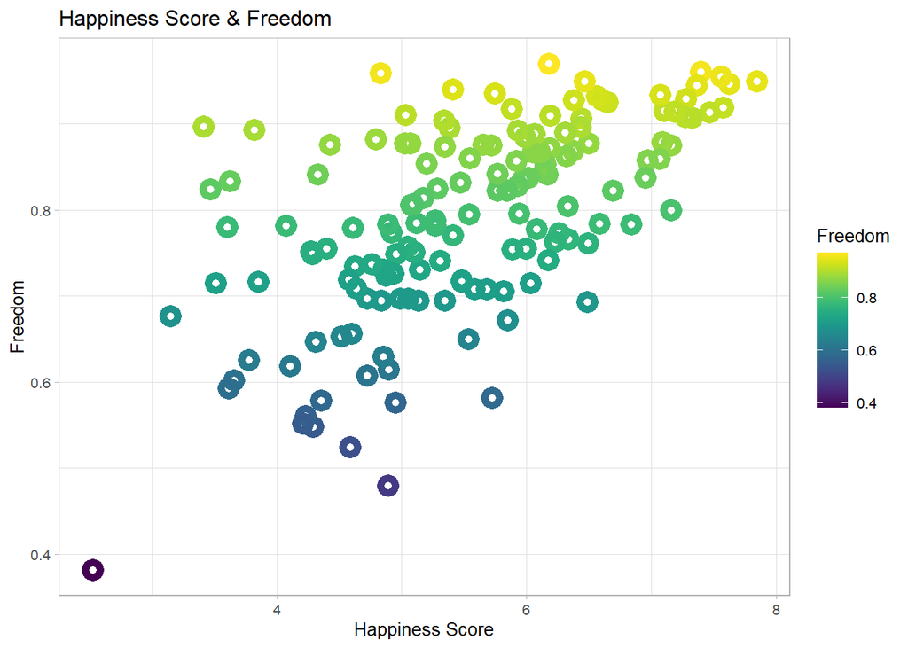

```r
ggplot(data = data, aes(x = Happiness_score, y =  Freedom)) +
  geom_point(aes(color = Freedom), show.legend = T, pch=1, stroke=3, size = 2) +
  theme_light(base_size = 10) + scale_color_viridis(discrete = F) +
  labs(title = "Happiness Score & Freedom", fill = "Happiness Score",
       x = "Happiness Score" , y = "Freedom")
```

> As predicted this plot shows that as freedom increases so does the happiness score, but we do not know if this relationship is causal and there may be confounds.

# 2.e. Happiness Score & Corruption

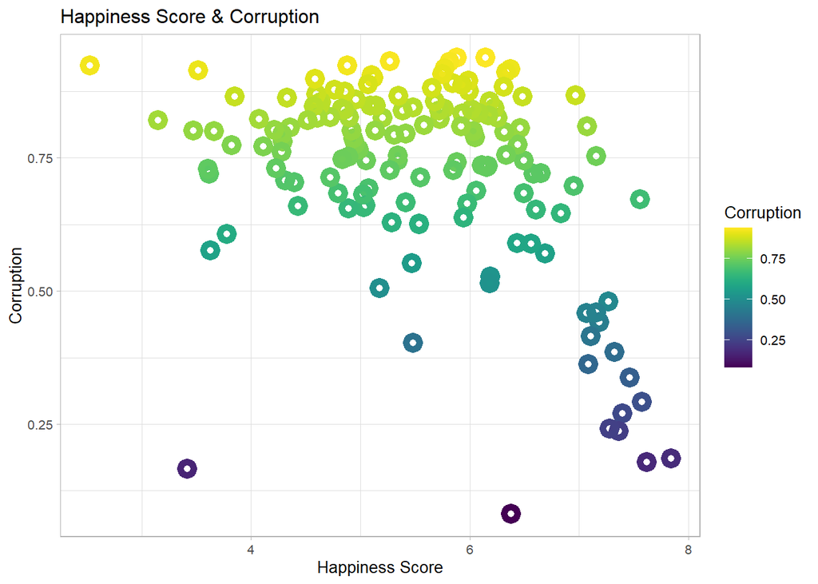

```r
ggplot(data = data, aes(x = Happiness_score, y =  Corruption)) +
  geom_point(aes(color = Corruption), show.legend = T, pch=1, stroke=3, size = 2) +
  theme_light(base_size = 10) + scale_color_viridis(discrete = F) +
  labs(title = "Happiness Score & Corruption", fill = "Happiness Score",
       x = "Happiness Score" , y = "Corruption")
```

# 2.f. Happiness Score & Generosity

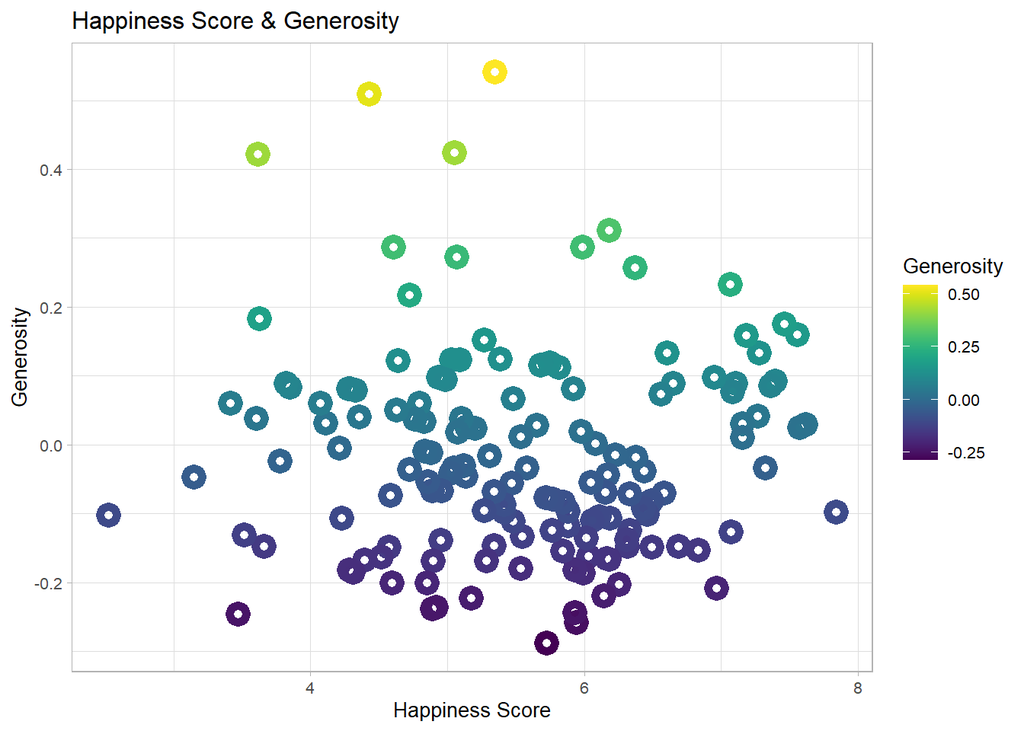

```r
ggplot(data = data, aes(x = Happiness_score, y =  Generosity)) +
  geom_point(aes(color = Generosity), show.legend = T, pch=1, stroke=3, size = 2) +
  theme_light(base_size = 10) + scale_color_viridis(discrete = F) +
  labs(title = "Happiness Score & Generosity", fill = "Happiness Score",
       x = "Happiness Score" , y = "Generosity")
```

> The plot may not show a clear relationship between these variables. This may be due to various factors such as the nature of the data, the measurement scales used, or the presence of outliers. Therefore, further analysis and statistical tests may be necessary to fully understand the relationship between happiness score and generosity.

# 2.g. Happiness Score & Dystopia_residual

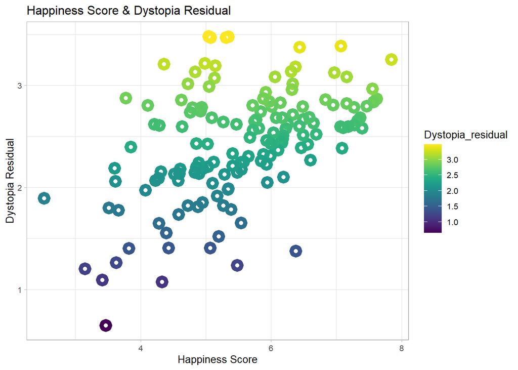

```r
ggplot(data = data, aes(x = Happiness_score, y =  Dystopia_residual)) +
  geom_point(aes(color = Dystopia_residual), show.legend = T, pch=1, stroke=3, size = 2) +
  theme_light(base_size = 10) + scale_color_viridis(discrete = F) +
  labs(title = "Happiness Score & Dystopia Residual", fill = "Happiness Score",
       x = "Happiness Score" , y = "Dystopia Residual")
```

> This plot shows that there appears to be a pretty significant relationship between Dystopia residual and the happiness score as the data points appear to show a positive trend.

# 3. Happiness Score & Region

# 3.a. Regionwise Happiness score using overlay barplot

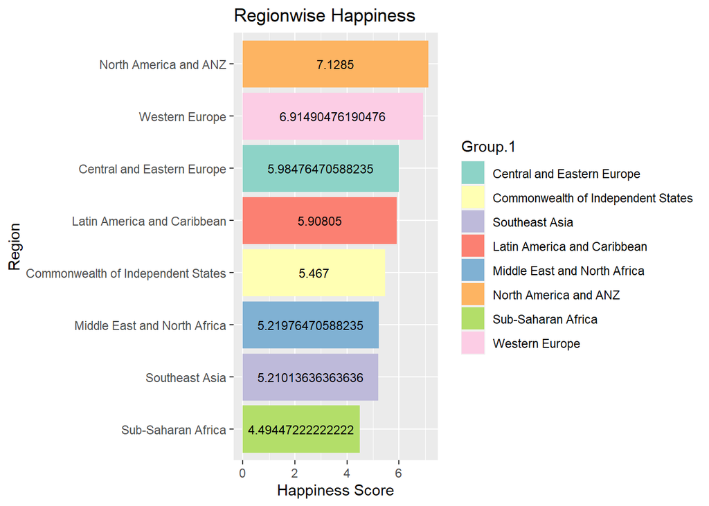

```r
data_means <- aggregate(dataRegion$Happiness_score, list(dataRegion$Region), mean)

data_means %>% arrange(desc(x)) %>% ggplot(aes(x = x, y = reorder(Group.1, x),  fill = Group.1)) +
  geom_bar(stat = "identity") +
  labs(title = "Regionwise Happiness") +
  ylab("Region") +
  xlab("Happiness Score") +
  scale_fill_brewer(palette = "Set3") +
  geom_text(aes(label = x), position=position_stack(vjust=0.5),color="black",size=3)
```

> The above barplot gives the region wise Happiness Score from highest to lowest.

# 3.b. Happiness score and Region boxplot

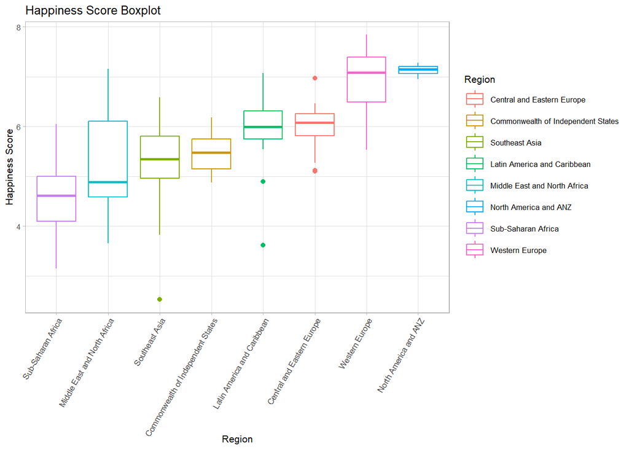

```r
ggplot(dataRegion, aes(x=reorder(Region,Happiness_score,FUN=median), y= Happiness_score, colour = Region)) +
  geom_boxplot() +
  theme_light(base_size = 8)+
  theme(axis.text.x = element_text(angle = 60, hjust = 1)) +
  labs(title = "Happiness Score Boxplot",x = "Region", y = "Happiness Score")
```

> We are using boxplot to display the distribution of a continuous variable Happiness score broken down by a categorical variable Region. From the above boxplot, we can say that North America and ANZ has maximum happiness score and Sub-Saharan Africa has lowest happiness score.

# 4. Number of countries per Region using overlay barplot

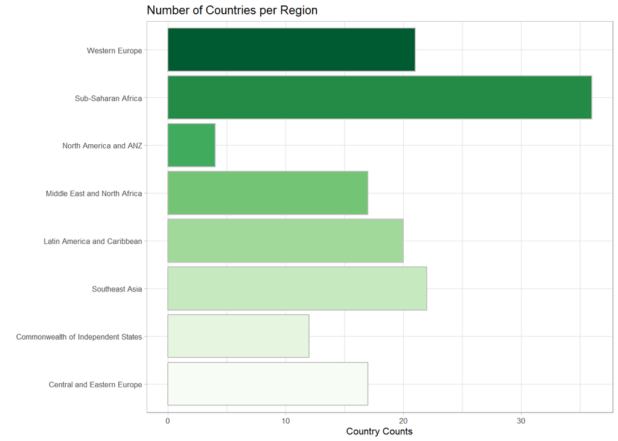

```r
ggplot(dataRegion, aes(Region, fill = Region)) +
  geom_bar(stat = "count", show.legend = F, color = 'gray') +
  scale_fill_brewer(palette = "Greens") + coord_flip() +
  labs(x = "", fill = "Region", y = "Country Counts",
       title = "Number of Countries per Region") +
  theme_light(base_size = 8)
```

> The resulting plot shows the number of countries per region, with each region represented by a colored bar. The plot can be used to get a quick overview of how the countries are distributed across different regions. The “Greens” color palette helps to differentiate between regions. Since the y-axis represents the count of countries, the plot can also be used to identify regions with more or fewer countries.

# 5. Exploratory data analysis of Region with other variables.

# Combine Regions to reduce number of categories

```r
dataRegionCat <- dataRegion %>%
  mutate(Region = fct_recode(Region,
                            # new name         old name
                            "Africa" = "Sub-Saharan Africa",
                            "ME"     = "Middle East and North Africa",
                            "N AMR"  = "North America and ANZ",
                            "CIS"    = "Commonwealth of Independent States",
                            "S AMR"  = "Latin America and Caribbean",
                            "SE Asia"= "Southeast Asia",
                            "EUR"    = "Central and Eastern Europe",
                            "EUR"    = "Western Europe" ))
#Reviewing the cropped names of Region column
dataRegionCat
```

```
##          Country  Region Happiness_score    GDP Social_support Life_expectancy
##   1:     Finland     EUR           7.842 10.775          0.954          72.000
##   2:     Denmark     EUR           7.620 10.933          0.954          72.700
##   3: Switzerland     EUR           7.571 11.117          0.942          74.400
##   4:     Iceland     EUR           7.554 10.878          0.983          73.000
##   5: Netherlands     EUR           7.464 10.932          0.942          72.400
##  ---
## 145:     Lesotho  Africa           3.512  7.926          0.787          48.700
## 146:    Botswana  Africa           3.467  9.782          0.784          59.269
## 147:      Rwanda  Africa           3.415  7.676          0.552          61.400
## 148:    Zimbabwe  Africa           3.145  7.943          0.750          56.201
## 149: Afghanistan SE Asia           2.523  7.695          0.463          52.493
##      Freedom Generosity Corruption Dystopia_residual
##   1:   0.949     -0.098      0.186             3.253
##   2:   0.946      0.030      0.179             2.868
##   3:   0.919      0.025      0.292             2.839
##   4:   0.955      0.160      0.673             2.967
##   5:   0.913      0.175      0.338             2.798
##  ---
## 145:   0.715     -0.131      0.915             1.800
## 146:   0.824     -0.246      0.801             0.648
## 147:   0.897      0.061      0.167             1.095
## 148:   0.677     -0.047      0.821             1.205
## 149:   0.382     -0.102      0.924             1.895
```

## Create a new factor variable called score

```r
# Create a New Factor Variable for Happiness    ############

mn = min(dataRegionCat$Happiness_score)
mx = max(dataRegionCat$Happiness_score)
b = (mx - mn)/3.0
brk = seq(from = (mn-0.001), to = mx, by = b)

# create new categorical variable
dataRegionCat$Score <- cut(dataRegionCat$Happiness_score, breaks = brk,labels = c("Low", "Medium", "High"))
dataRegionCat <- dataRegionCat %>% drop_na()

#Reviewing Score column in dataset
dataRegionCat
```

```
##          Country  Region Happiness_score    GDP Social_support Life_expectancy
##   1:     Denmark     EUR           7.620 10.933          0.954          72.700
##   2: Switzerland     EUR           7.571 11.117          0.942          74.400
##   3:     Iceland     EUR           7.554 10.878          0.983          73.000
##   4: Netherlands     EUR           7.464 10.932          0.942          72.400
##   5:      Norway     EUR           7.392 11.053          0.954          73.300
##  ---
## 144:     Lesotho  Africa           3.512  7.926          0.787          48.700
## 145:    Botswana  Africa           3.467  9.782          0.784          59.269
## 146:      Rwanda  Africa           3.415  7.676          0.552          61.400
## 147:    Zimbabwe  Africa           3.145  7.943          0.750          56.201
## 148: Afghanistan SE Asia           2.523  7.695          0.463          52.493
##      Freedom Generosity Corruption Dystopia_residual Score
##   1:   0.946      0.030      0.179             2.868  High
##   2:   0.919      0.025      0.292             2.839  High
##   3:   0.955      0.160      0.673             2.967  High
##   4:   0.913      0.175      0.338             2.798  High
##   5:   0.960      0.093      0.270             2.580  High
##  ---
## 144:   0.715     -0.131      0.915             1.800   Low
## 145:   0.824     -0.246      0.801             0.648   Low
## 146:   0.897      0.061      0.167             1.095   Low
## 147:   0.677     -0.047      0.821             1.205   Low
## 148:   0.382     -0.102      0.924             1.895   Low
```

# 5.a. Region by Happiness Score

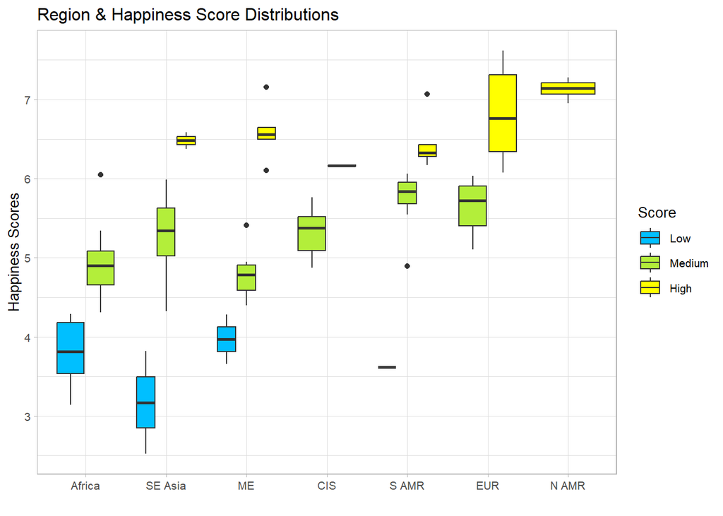

```r
ggplot(data = dataRegionCat, aes(x = reorder(Region, Happiness_score),
                     y = Happiness_score, fill = Score)) +
  geom_boxplot(show.legend = T) +
  labs(x = "", fill = "Score", y = "Happiness Scores",
       title = "Region & Happiness Score Distributions") +
  scale_fill_manual(values = c("deepskyblue","olivedrab2", "yellow")) +
  theme_light(base_size = 10)
```

# 5.b. Region by GDP per Capita

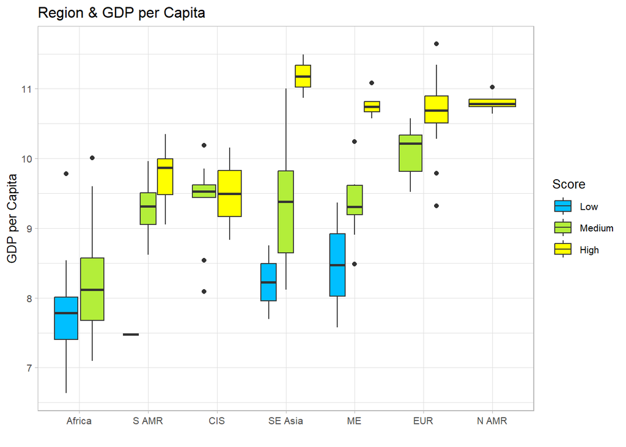

```r
ggplot(data = dataRegionCat, aes(x = reorder(Region, GDP),
                     y = GDP, fill = Score)) +
  geom_boxplot(show.legend = T) +
  labs(x = "", fill = "Score", y = "GDP per Capita",
       title = "Region & GDP per Capita") +
  scale_fill_manual(values = c("deepskyblue","olivedrab2", "yellow")) +
  theme_light(base_size = 10)
```

# 5.c. Region by Life Expectancy

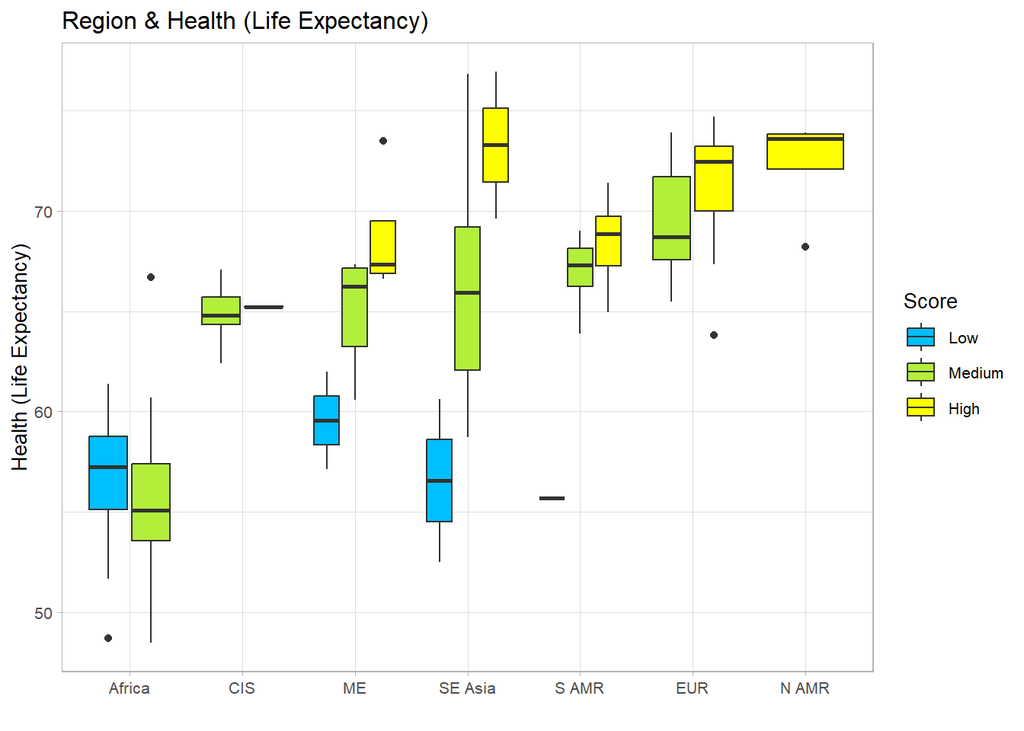

```r
ggplot(data = dataRegionCat, aes(x = reorder(Region, Life_expectancy),
                     y = Life_expectancy, fill = Score)) +
  geom_boxplot(show.legend = T) +
  labs(x = "", fill = "Score", y = "Health (Life Expectancy)",
       title = "Region & Health (Life Expectancy)") +
  scale_fill_manual(values = c("deepskyblue","olivedrab2", "yellow")) +
  theme_light(base_size = 10)
```

> Overall, this plot shows the distribution of Life Expectancy across different regions of the world, colored by their respective Happiness Scores. We can see that there is variation in Life Expectancy among different regions, with some having higher median values than others. Additionally, we can observe that countries with higher Happiness Scores tend to have higher Life Expectancy values, indicating a positive relationship between these two variables.

# 5.d. Region by Government Corruption

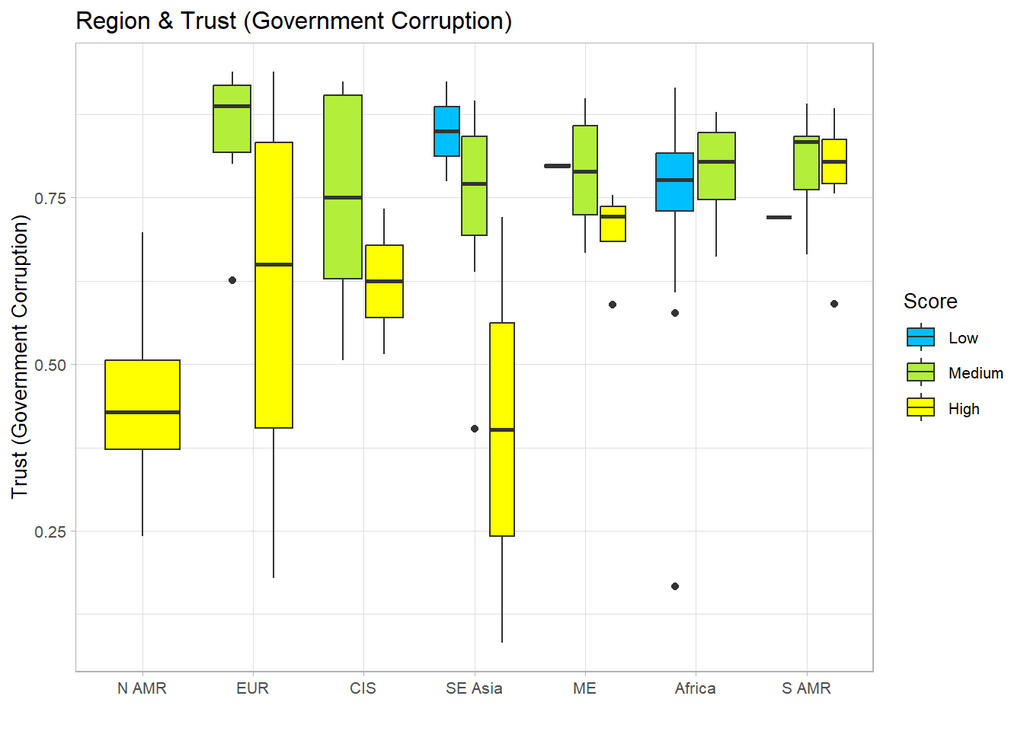

```r
ggplot(data = dataRegionCat, aes(x = reorder(Region, Corruption),
                     y = Corruption, fill = Score)) +
  geom_boxplot(show.legend = T) +
  labs(x = "", fill = "Score", y = "Trust (Government Corruption)",
       title = "Region & Trust (Government Corruption)") +
  scale_fill_manual(values = c("deepskyblue","olivedrab2", "yellow")) +
  theme_light(base_size = 10)
```

> Overall, this plot suggests that there is a wide variation in the level of trust in government across different regions, with some regions showing higher levels of trust than others. It also shows that there is some relationship between happiness score and level of trust, with some of the highest scoring regions also showing higher levels of trust.

# 5.e. Region by Freedom

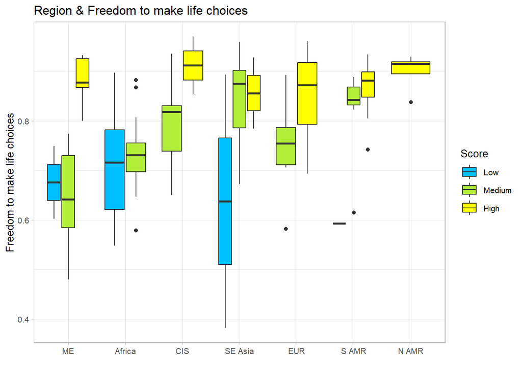

```r
ggplot(data = dataRegionCat, aes(x = reorder(Region, Freedom),
                     y = Freedom, fill = Score)) +
  geom_boxplot(show.legend = T) +
  labs(x = "", fill = "Score", y = "Freedom to make life choices",
       title = "Region & Freedom to make life choices") +
  scale_fill_manual(values = c("deepskyblue","olivedrab2", "yellow")) +
  theme_light(base_size = 10)
```

# 5.f. Region by Generosity

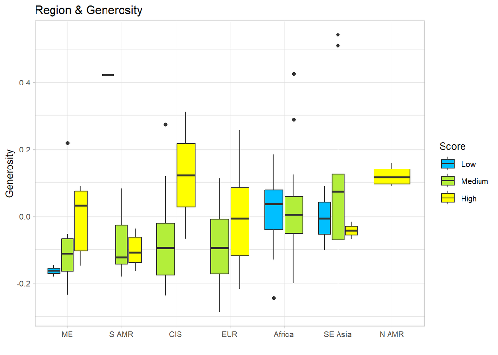

```r
ggplot(data = dataRegionCat, aes(x = reorder(Region, Generosity),
                     y = Generosity, fill = Score)) +
  geom_boxplot(show.legend = T) +
  labs(x = "", fill = "Score", y = "Generosity",
       title = "Region & Generosity") +
  scale_fill_manual(values = c("deepskyblue","olivedrab2", "yellow")) +
  theme_light(base_size = 10)
```

> Overall, this plot suggests that generosity varies significantly across regions and may be related to regional differences in happiness scores.

# 5.g. Region by Social Support

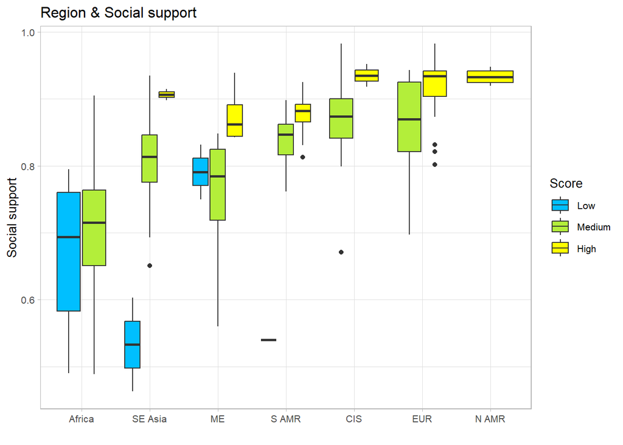

```r
ggplot(data = dataRegionCat, aes(x = reorder(Region, Social_support),
                     y = Social_support, fill = Score)) +
  geom_boxplot(show.legend = T) +
  labs(x = "", fill = "Score", y = "Social support",
       title = "Region & Social support") +
  scale_fill_manual(values = c("deepskyblue","olivedrab2", "yellow")) +
  theme_light(base_size = 10)
```

> Overall, the plot shows that there are substantial differences in the distribution of “Social support” across different regions of the world.

# 5.h. Region by Dystopia Residual

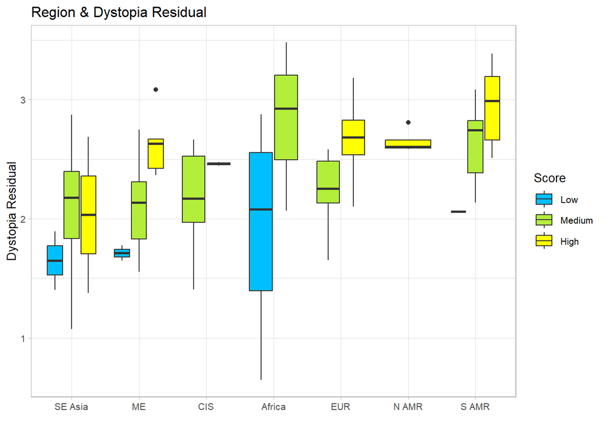

```r
ggplot(data = dataRegionCat, aes(x = reorder(Region, Dystopia_residual),
                     y = Dystopia_residual, fill = Score)) +
  geom_boxplot(show.legend = T) +
  labs(x = "", fill = "Score", y = "Dystopia Residual",
       title = "Region & Dystopia Residual") +
  scale_fill_manual(values = c("deepskyblue","olivedrab2", "yellow")) +
  theme_light(base_size = 10)
```

> Overall, this plot shows the distribution of Dystopia_residual values across different regions, and allows for easy comparison between regions based on their boxplot shapes and median values.

# STEP 7 : HYPOTHESIS TEST :

# The target variable Happiness score is slightly skewed as discussed above and follows nearly a normal distribution, so we will be using T-statistic instead of Z-statisitc.

# 1. Hypothesis test for one mean

# Creating a separate dataset for South East Asia.

```r
Southeast_Asia_Data <- subset(data, Region == "Southeast Asia")
Southeast_Asia_Data
```

```
##        Country         Region Happiness_score    GDP Social_support
## 1:   Singapore Southeast Asia           6.377 11.488          0.915
## 2:    Thailand Southeast Asia           5.985  9.805          0.888
## 3: Philippines Southeast Asia           5.880  9.076          0.830
## 4:     Vietnam Southeast Asia           5.411  8.973          0.850
## 5:    Malaysia Southeast Asia           5.384 10.238          0.817
## 6:   Indonesia Southeast Asia           5.345  9.365          0.811
## 7:        Laos Southeast Asia           5.030  8.947          0.728
## 8:    Cambodia Southeast Asia           4.830  8.360          0.765
## 9:     Myanmar Southeast Asia           4.426  8.541          0.779
##    Life_expectancy Freedom Generosity Corruption Dystopia_residual
## 1:          76.953   0.927     -0.018      0.082             1.379
## 2:          67.401   0.884      0.287      0.895             2.309
## 3:          62.000   0.917     -0.097      0.742             2.872
## 4:          68.034   0.940     -0.098      0.796             2.211
## 5:          67.102   0.895      0.125      0.839             1.784
## 6:          62.236   0.873      0.542      0.867             1.987
## 7:          58.968   0.910      0.123      0.658             2.204
## 8:          62.000   0.959      0.034      0.843             2.148
## 9:          59.302   0.876      0.509      0.660             1.407
```

# Reviewing Summary of South East Asia

```r
summary(Southeast_Asia_Data)
```

```
##    Country             Region          Happiness_score      GDP
##  Length:9           Length:9           Min.   :4.426   Min.   : 8.360
##  Class :character   Class :character   1st Qu.:5.030   1st Qu.: 8.947
##  Mode  :character   Mode  :character   Median :5.384   Median : 9.076
##                                        Mean   :5.408   Mean   : 9.421
##                                        3rd Qu.:5.880   3rd Qu.: 9.805
##                                        Max.   :6.377   Max.   :11.488
##  Social_support   Life_expectancy    Freedom        Generosity
##  Min.   :0.7280   Min.   :58.97   Min.   :0.873   Min.   :-0.0980
##  1st Qu.:0.7790   1st Qu.:62.00   1st Qu.:0.884   1st Qu.:-0.0180
##  Median :0.8170   Median :62.24   Median :0.910   Median : 0.1230
##  Mean   :0.8203   Mean   :64.89   Mean   :0.909   Mean   : 0.1563
##  3rd Qu.:0.8500   3rd Qu.:67.40   3rd Qu.:0.927   3rd Qu.: 0.2870
##  Max.   :0.9150   Max.   :76.95   Max.   :0.959   Max.   : 0.5420
##    Corruption     Dystopia_residual
##  Min.   :0.0820   Min.   :1.379
##  1st Qu.:0.6600   1st Qu.:1.784
##  Median :0.7960   Median :2.148
##  Mean   :0.7091   Mean   :2.033
##  3rd Qu.:0.8430   3rd Qu.:2.211
##  Max.   :0.8950   Max.   :2.872
```

# Visualize the Southeast_Asia data using Boxplot.

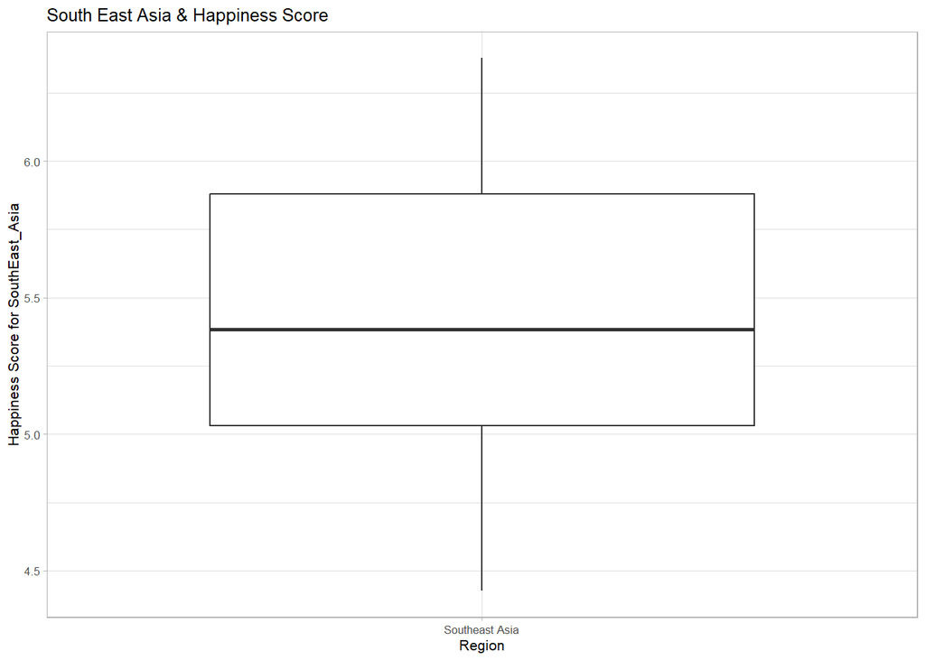

```r
ggplot(data = Southeast_Asia_Data, aes(x = reorder(Region, Happiness_score),
                     y = Happiness_score)) +
  geom_boxplot(show.legend = T) +
  labs(x = "Region", y = "Happiness Score for SouthEast_Asia",
       title = "South East Asia & Happiness Score") +
  theme_light(base_size = 8)
```

# Preliminary test to check one-sample t-test assumptions:

# 1. Is this a large sample? - No, because n < 30 while n = 9.

# 2. To check whether the data follow a normal distribution:

# 2.1 Shapiro-Wilk test:

# H0: NULL Hypothesis : the data are normally distributed

# H1: Alternative Hypothesis : The data is not normally distributed

```r
shapiro.test(Southeast_Asia_Data$Happiness_score)
```

```
##
##  Shapiro-Wilk normality test
##
## data:  Southeast_Asia_Data$Happiness_score
## W = 0.98021, p-value = 0.9654
```

> The output of this test will include a p-value. If the p-value is greater than 0.05, then we cannot reject the null hypothesis that the data is normally distributed. If the p-value is less than 0.05, then we can reject the null hypothesis and conclude that the data is not normally distributed. Here in South East Asia data, pvalue > 0.05 implying that the distribution of the data are not significantly different from normal distribution. In other words, we can assume the normality.

# 2.2 QQ Plot:

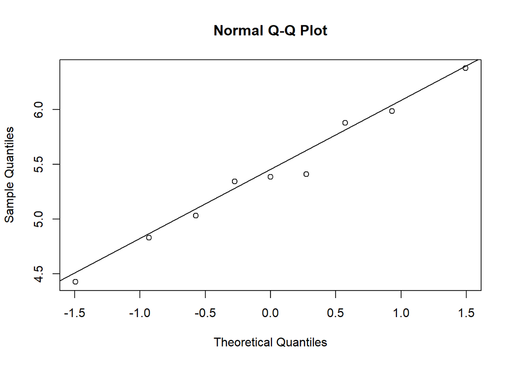

```r
qqnorm(Southeast_Asia_Data$Happiness_score)
qqline(Southeast_Asia_Data$Happiness_score)
```

> Another way to check for normality is to use a quantile-quantile plot (QQ plot). A QQ plot compares the quantiles of your data to the quantiles of a theoretical normal distribution. If the data is normally distributed, the points on the plot will fall along a straight line. From the above normality plots, we conclude that the data may come from normal distributions.

# HYPOTHESIS TEST For one mean:

# H0 : NULL Hypothesis : Average Happiness score of countires in SouthEast Asia is 5.

# H1 : Alternative Hypothesis : Average Happiness score of countires in SouthEast Asia is not equal to 5.

# μ : Mean of Happiness scores of South Asia

# H0: μ = 5

# H1: μ ≠ 5

# Manual calculations

```r
mu <- 5 #Population mean as per Hypothesis
xbar <- mean(Southeast_Asia_Data$Happiness_score) #Sample mean
s <- sd(Southeast_Asia_Data$Happiness_score) #Sample Standard Deviation
n <- nrow(Southeast_Asia_Data) #Sample size

stdError <- s/sqrt(n) #Standard error
df <- n-1 #Degree of freedom
ci <- 0.95 #Confidence interval
alpha <- 1-ci #Significance level
tstatistic <- (xbar - mu)/stdError #T-statistic
tvalue <- qt(1-alpha/2,df) #Critical value of t-distribution

lowerbound <- xbar - tvalue*stdError #lower bound of confidence interval
upperbound <- xbar + tvalue*stdError #upper bound of confidence interval

p_value <- 2 * (1 - pt(abs(tstatistic), df)) #p-value

cat("Sample size is:",n)
```

```
## Sample size is: 9
```

```r
cat("\nT-Statistic value is :",tstatistic)
```

```
##
## T-Statistic value is : 2.016699
```

```r
cat("\nDegree of freedom is :",df)
```

```
##
## Degree of freedom is : 8
```

```r
cat("\np-value is :",p_value)
```

```
##
## p-value is : 0.07845914
```

```r
cat("\nTrue mean value is :",mu)
```

```
##
## True mean value is : 5
```

```r
cat("\nConfidence Interval is :",ci*100,"%")
```

```
##
## Confidence Interval is : 95 %
```

```r
cat("\nLowerbound for confidence interval is :",lowerbound)
```

```
##
## Lowerbound for confidence interval is : 4.941534
```

```r
cat("\nUpperbound for confidence interval is :",upperbound)
```

```
##
## Upperbound for confidence interval is : 5.873577
```

```r
cat("\nMean of Sample is :",xbar)
```

```
##
## Mean of Sample is : 5.407556
```

# One sample t-test : One-sample t-test is used to compare the mean of one sample to a known standard (or theoretical/hypothetical) mean.

```r
t.test(Southeast_Asia_Data$Happiness_score, mu = 5, conf.level = .95)
```

```
##
##  One Sample t-test
##
## data:  Southeast_Asia_Data$Happiness_score
## t = 2.0167, df = 8, p-value = 0.07846
## alternative hypothesis: true mean is not equal to 5
## 95 percent confidence interval:
##  4.941534 5.873577
## sample estimates:
## mean of x
##  5.407556
```

# 2. Hypothesis test for 2 mean

# Creating two independent dataset.

```r
Cen_East_Europe_data <- subset(data, Region == "Central and Eastern Europe")
West_Europe_data <- subset(data, Region == "Western Europe")

Europe_data = rbind(Cen_East_Europe_data, West_Europe_data)
Europe_data
```

```
##                    Country                     Region Happiness_score    GDP
##  1:         Czech Republic Central and Eastern Europe           6.965 10.556
##  2:               Slovenia Central and Eastern Europe           6.461 10.529
##  3:                 Kosovo Central and Eastern Europe           6.372  9.318
##  4:               Slovakia Central and Eastern Europe           6.331 10.369
##  5:              Lithuania Central and Eastern Europe           6.255 10.499
##  6:                Estonia Central and Eastern Europe           6.189 10.481
##  7:                 Poland Central and Eastern Europe           6.166 10.382
##  8:                Romania Central and Eastern Europe           6.140 10.284
##  9:                 Serbia Central and Eastern Europe           6.078  9.787
## 10:                 Latvia Central and Eastern Europe           6.032 10.315
## 11:                Hungary Central and Eastern Europe           5.992 10.358
## 12:                Croatia Central and Eastern Europe           5.882 10.217
## 13: Bosnia and Herzegovina Central and Eastern Europe           5.813  9.590
## 14:             Montenegro Central and Eastern Europe           5.581  9.940
```

[output cut: 105 more lines]

# Reviewing Summary of Europe

```r
#summary statistics by groups
group_by(Europe_data, Region) %>% summarise(count = n(),
                                            mean = mean(Happiness_score, na.rm = TRUE),
                                            sd = sd(Happiness_score, na.rm = TRUE))
```

```
## # A tibble: 2 × 4
##   Region                     count  mean    sd
##   <chr>                      <int> <dbl> <dbl>
## 1 Central and Eastern Europe    17  5.98 0.493
## 2 Western Europe                21  6.91 0.657
```

# Visualize the Europe data using Boxplot.

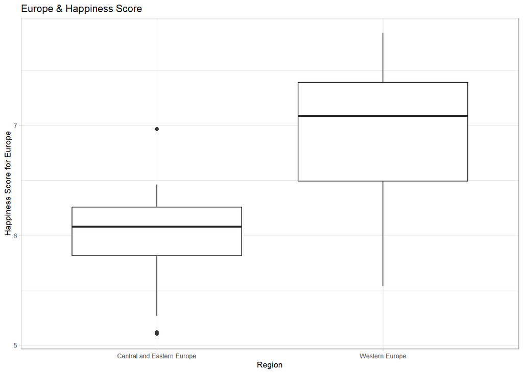

```r
ggplot(data = Europe_data, aes(x = reorder(Region, Happiness_score),
                     y = Happiness_score)) +
  geom_boxplot(show.legend = T) +
  labs(x = "Region", y = "Happiness Score for Europe",
       title = "Europe & Happiness Score") +
  theme_light(base_size = 8)
```

> the above plot states that Western Europe has more median Happiness score as compared to Central and Eastern Europe.

# Preliminary test to check independent sample t-test assumptions:

# 1. Are the two samples independent?

# Yes, since scores from Central and Eastern European countries and Western European countries are not related.

# 2. To check whether the data follow a normal distribution:

# 2.1 Shapiro-Wilk test:

# H0: NULL Hypothesis : the data are normally distributed

# H1: Alternative Hypothesis : The data is not normally distributed

```r
shapiro.test(Cen_East_Europe_data$Happiness_score)
```

```
##
##  Shapiro-Wilk normality test
##
## data:  Cen_East_Europe_data$Happiness_score
## W = 0.94045, p-value = 0.3236
```

```r
shapiro.test(West_Europe_data$Happiness_score)
```

```
##
##  Shapiro-Wilk normality test
##
## data:  West_Europe_data$Happiness_score
## W = 0.93208, p-value = 0.1515
```

> The output of this test will include a p-value. If the p-value is greater than 0.05, then we cannot reject the null hypothesis that the data is normally distributed. If the p-value is less than 0.05, then we can reject the null hypothesis and conclude that the data is not normally distributed. Here in Central and Eastern and Western European data, pvalue > 0.05 implying that the distribution of the data are not significantly different from normal distribution. In other words, we can assume the normality.

# 2.2 QQ Plot:

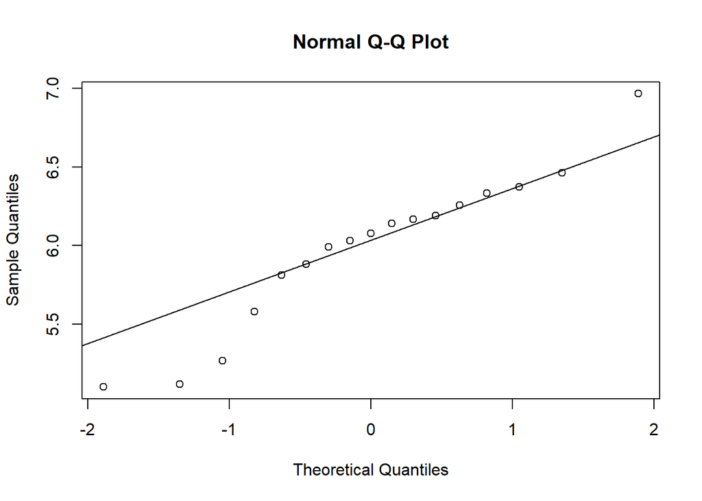

```r
qqnorm(Cen_East_Europe_data$Happiness_score)
qqline(Cen_East_Europe_data$Happiness_score)
```

> Another way to check for normality is to use a quantile-quantile plot (QQ plot). A QQ plot compares the quantiles of your data to the quantiles of a theoretical normal distribution. If the data is normally distributed, the points on the plot will fall along a straight line. From the above normality plots, we conclude that the data may come from normal distributions.

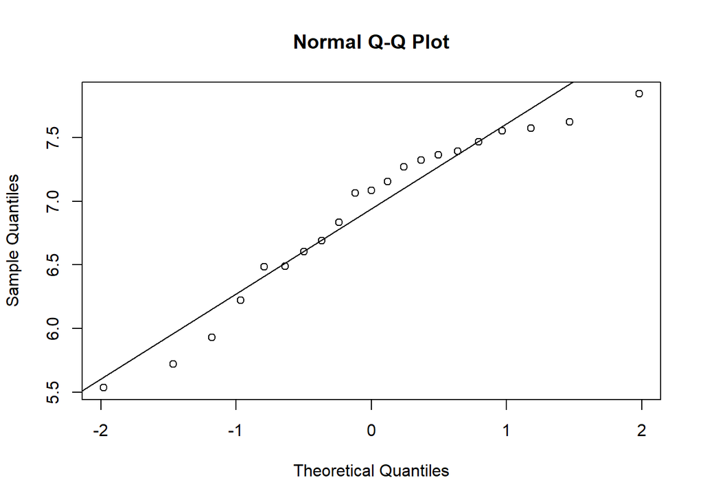

```r
qqnorm(West_Europe_data$Happiness_score)
qqline(West_Europe_data$Happiness_score)
```

> Another way to check for normality is to use a quantile-quantile plot (QQ plot). A QQ plot compares the quantiles of your data to the quantiles of a theoretical normal distribution. If the data is normally distributed, the points on the plot will fall along a straight line. From the above normality plots, we conclude that the data may come from normal distributions.

# Hypothesis test For Difference in Variance :

# A hypothesis test for two independent population variances can be used to determine whether or not the data provide statistical evidence of a difference in the variance of the Happiness score between Central and Eastern European countries and Western European countries.